# Fisheries Performance Assessment Toolkit

User Manual

Tom Carruthers tom@bluematterscience.com

Adrian Hordyk adrian@bluematterscience.com

24 June, 2021

[figure not shown]

[figure not shown]

[figure not shown]

# 1 Introduction

## 1.1 Coastal Fisheries Initiative

The Coastal Fisheries Initiative [(CFI)](http://www.fao.org/in-action/coastal-fisheries-initiative/en/) is a global effort to preserve marine resources and ensure that coastal fisheries can continue to play their crucial role in society, contributing to food security, as well as economic and social development.

Funded by the Global Environment Facility (GEF), the initiative rallies UN agencies and international conservation organizations behind the common goal of promoting the sustainable use and management of coastal fisheries, championing innovative approaches to improve governance and strengthening the seafood value chain.

CFI provides financial and hands-on technical support to coastal fisheries in six countries across three geographies: Indonesia, Latin America (Ecuador and Peru) and West Africa (Cape Verde, Côte d’Ivoire and Senegal).

## 1.2 Fisheries Performance Assessment Toolkit (FPAT)

To measure the impact of the Coastal Fisheries Initiative (CFI), future performance must be compared to a baseline starting point. The measurement tool chosen by the CFI is the Fisheries Performance Assessment Toolkit (FPAT), developed specifically for monitoring and evaluation of the CFI and built on the notion that an “effective management system is one that is ecologically sustainable, socially acceptable, and generates sustainable resource rents or profits.” (Anderson et al., 2016).

The FPAT relies on data from a variety of sources ranging from the technical to the informal. This handbook offers a step-by-step guide to collecting the data necessary for completing an assessment using the FPAT, including how to choose data sources, evaluate data quality, and integrate desk research and fieldwork.

The Fisheries Performance Assessment Toolkit [(FPAT)](https://apps.bluematterscience.com/FPATbeta/) is a browser-based application designed to evaluate the ecological, economic, and social performance of a wide range of fisheries.

FPAT includes two tools:

1. [Fisheries Performance Indicators](https://www.fpilab.org/): a tool designed to determine how fisheries management systems are performing in order to achieve community, economic, and ecological sustainability.
2. [openMSE](https://openmse.com/): an open-source framework for evaluating the performance of alternative modes of management for a fishery.

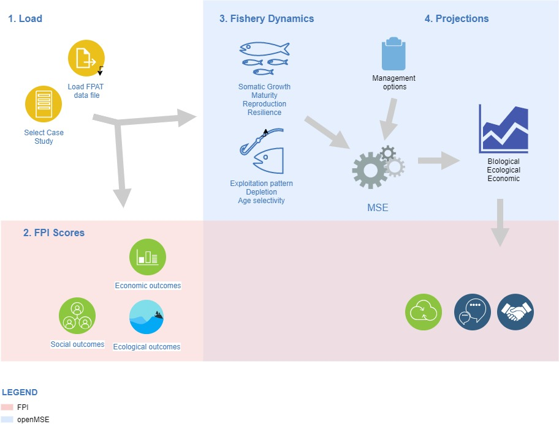

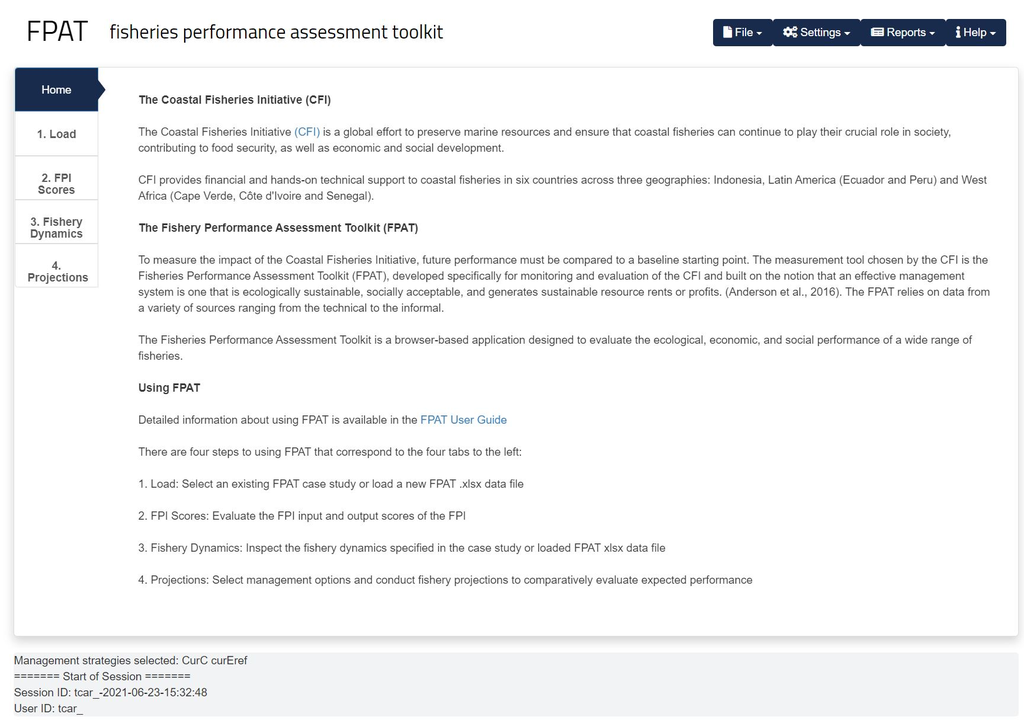

## 1.3 Fishery Performance Indicators (FPI, University of Washington)

FPIs were developed to facilitate a rapid assessment of the economic, social, and ecological performance of fishery systems around the world. By using the same format to evaluate fisheries ranging from small-scale shellfish fisheries to industrialized, offshore tuna boats, FPIs allow for meaningful comparison between subsets of fisheries (for example, all crab fisheries assessed in less-developed countries) or against a worldwide database of assessed fisheries. Thus, FPIs can be used to evaluate the effectiveness of management interventions, investment, and reforms, and to identify opportunities for triple-bottom line improvements (McCluney et al., 2019).

FPIs utilize published data when available, but also incorporate expert judgement and interviews with key informants to “score” a fishery’s performance against the triple bottom line (ecological, economic, and social). Once research and fieldwork data are collected, FPI [assessments](https://drive.google.com/file/d/1JeJqm31eaMn6TaxV1RMbYU5DtiCMfj4p/view) are created by populating a template in spreadsheet software (e.g., Microsoft Excel). For the CFI FPAT assessments, a Governance Supplement has been added to the standard FPI format to better understand the effect of legal, social, economic, and political arrangements on fisheries management.